# Crime Data Analysis

Prajwal KC

## Introduction

Crime data analysis is essential for identifying patterns, trends, and areas requiring law enforcement attention. This report explores a publicly available U.S. crime dataset sourced from Kaggle. The goal is to analyze crime trends over time, examine state-wise distributions, and conduct an in-depth analysis of Los Angeles, California.

By understanding how crimes vary by time, region, and demographics, data analysts can provide valuable insights for crime prevention, policy planning, and public safety improvements.

## Dataset Description

The dataset includes nationwide crime reports across several years and states in the U.S. Key features include: - `Year`: The year the crime was reported - `State` and `City`: The location of the crime - `Crime Type`, `Weapon`, `Crime Solved`: Information about the crime event - `Victim Age`, `Victim Sex`, `Victim Race`, `Relationship`: Victim demographics

The dataset contains thousands of observations, offering sufficient depth for statistical and trend analysis.

## Load the Dataset

```r
library(readr)
US_Crime_DataSet_csv <- read_csv("US_Crime_DataSet.csv.zip")
View(US_Crime_DataSet_csv)
crimedata <- US_Crime_DataSet_csv
```

## Crime Types Overview

```r
unique(crimedata$`Crime Type`)
```

```
## [1] "Murder or Manslaughter"     "Manslaughter by Negligence"
```

```r
table(crimedata$`Crime Type`)
```

```
##
## Manslaughter by Negligence     Murder or Manslaughter
##                       9116                     629338
```

## Crime Trends Over Time

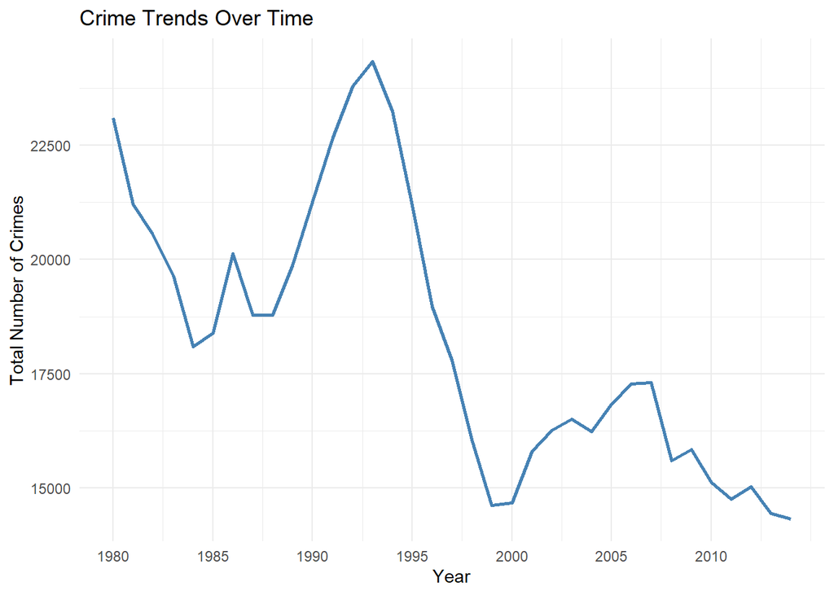

```r
total_crime <- crimedata %>%
  group_by(Year) %>%
  summarize(count = n())

ggplot(total_crime, aes(x = Year, y = count)) +
  geom_line(color = "steelblue", linewidth= 1) +
  scale_x_continuous(breaks = seq(min(total_crime$Year), max(total_crime$Year), by = 5)) +
  labs(
    x = "Year",
    y = "Total Number of Crimes",
    title = "Crime Trends Over Time")+
      theme_minimal()
```

## Statewise Crime Distribution

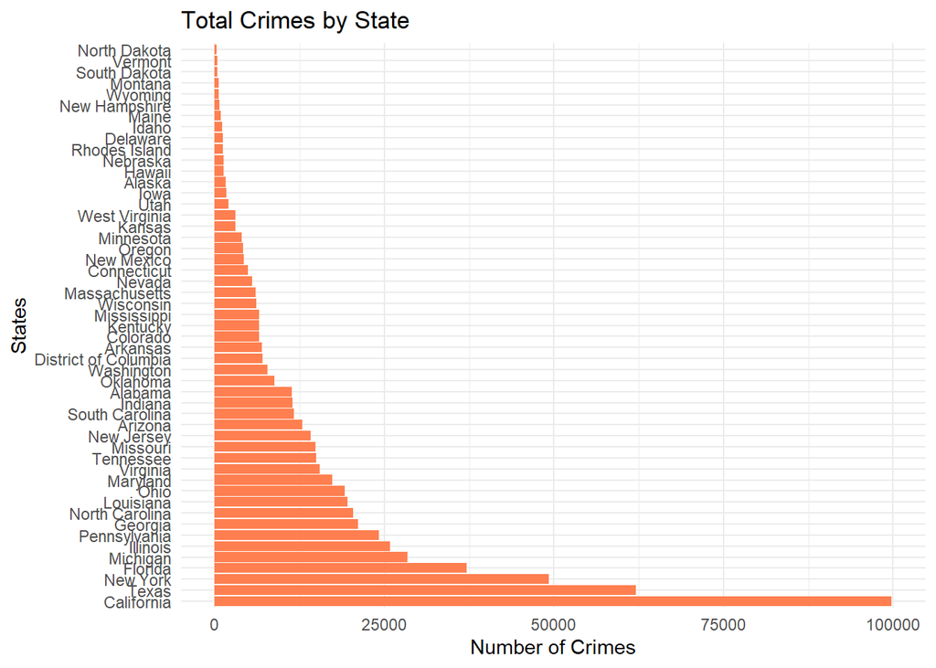

```r
statewise <- crimedata %>%
  group_by(State) %>%
  summarize(number = n())

ggplot(statewise, aes(x = reorder(State, -number), y = number)) +
  geom_col(fill = "coral") +
  coord_flip() +
  labs(title = "Total Crimes by State",
       y="Number of Crimes",
       x="States")+
         theme_minimal()
```

## Los Angeles Crime Focus

```r
LA <- crimedata %>% filter(City == "Los Angeles")

# Insight: This shows how many crimes were solved versus unsolved in LA.
LA %>% group_by(`Crime Solved`) %>% summarize(count = n())
```

```
## # A tibble: 2 × 2
##   `Crime Solved` count
##   <chr>          <int>
## 1 No             17810
## 2 Yes            26701
```

```r
# Insight: This shows the sex of victims.
LA %>% group_by(`Victim Sex`) %>% summarize(count = n())
```

```
## # A tibble: 3 × 2
##   `Victim Sex` count
##   <chr>        <int>
## 1 Female        6782
## 2 Male         37722
## 3 Unknown          7
```

```r
#Insight: This shows the race of victims.
LA %>% group_by(`Victim Race`) %>% summarize(count = n())
```

```
## # A tibble: 5 × 2
##   `Victim Race`                 count
##   <chr>                         <int>
## 1 Asian/Pacific Islander         1263
## 2 Black                         15678
## 3 Native American/Alaska Native    76
## 4 Unknown                         807
## 5 White                         26687
```

## Victim Age Group Distribution

```r
agegroup <- LA %>%
  mutate(agegroup = case_when(
    `Victim Age` < 5 ~ "Under 5",
    `Victim Age` >= 5 & `Victim Age` < 18 ~ "5-17",
    `Victim Age` >= 18 & `Victim Age` < 50 ~ "18-49",
    `Victim Age` >= 50 ~ "50+"
  ))

agegroup %>%
  group_by(agegroup) %>%
  summarize(count = n())
```

```
## # A tibble: 4 × 2
##   agegroup count
##   <chr>    <int>
## 1 18-49    34517
## 2 5-17      4120
## 3 50+       4861
## 4 Under 5   1013
```

## Weapons involved in LA crimes

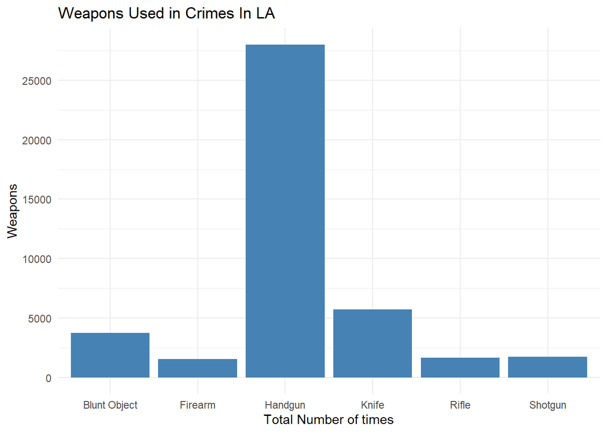

```r
weapon <- c("Handgun", "Knife", "Blunt Object", "Firearm", "Rifle", "Shotgun")

ggplot(data = subset(LA, Weapon %in% weapon), aes(x = Weapon)) +
  geom_bar(fill = "steelblue") +
  scale_y_continuous(breaks = seq(0, 25000, by = 5000)) +
  labs(title = "Weapons Used in Crimes In LA",
       x="Total Number of times",
       y="Weapons")+
         theme_minimal()
```

## Linear Regression on Total Crimes

```r
linear <- lm(count ~ Year, data = total_crime)
summary(linear)
```

```
##
## Call:
## lm(formula = count ~ Year, data = total_crime)
##
## Residuals:
##     Min      1Q  Median      3Q     Max
## -3191.7 -1153.0  -366.0   738.1  5235.8
##
## Coefficients:
##              Estimate Std. Error t value Pr(>|t|)
## (Intercept) 446416.80   68626.71   6.505 2.20e-07 ***
## Year          -214.41      34.36  -6.239 4.78e-07 ***
## ---
## Signif. codes:  0 '***' 0.001 '**' 0.01 '*' 0.05 '.' 0.1 ' ' 1
##
## Residual standard error: 2053 on 33 degrees of freedom
## Multiple R-squared:  0.5412, Adjusted R-squared:  0.5273
## F-statistic: 38.93 on 1 and 33 DF,  p-value: 4.779e-07
```

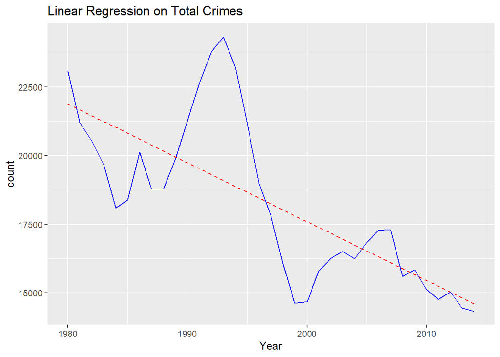

```r
total_crime$linearpred <- predict(linear, newdata = total_crime)

ggplot(total_crime, aes(x = Year, y = count)) +
  geom_line(color = "blue") +
  geom_line(aes(y = linearpred), color = "red", linetype = "dashed") +
  labs(title = "Linear Regression on Total Crimes")
```

## Conclusion

This analysis uncovered several valuable insights from the U.S. crime dataset:

- Crimes have shown varying trends over the years, with some periods of increase or decline.
- Certain states contribute disproportionately to national crime totals.
- Los Angeles, as a major urban area, shows distinct crime patterns — including common weapons used and age demographics.
- Linear regression analysis shows time-based trends which could help in forecasting and prevention strategies.